# Unsupervised_Learning

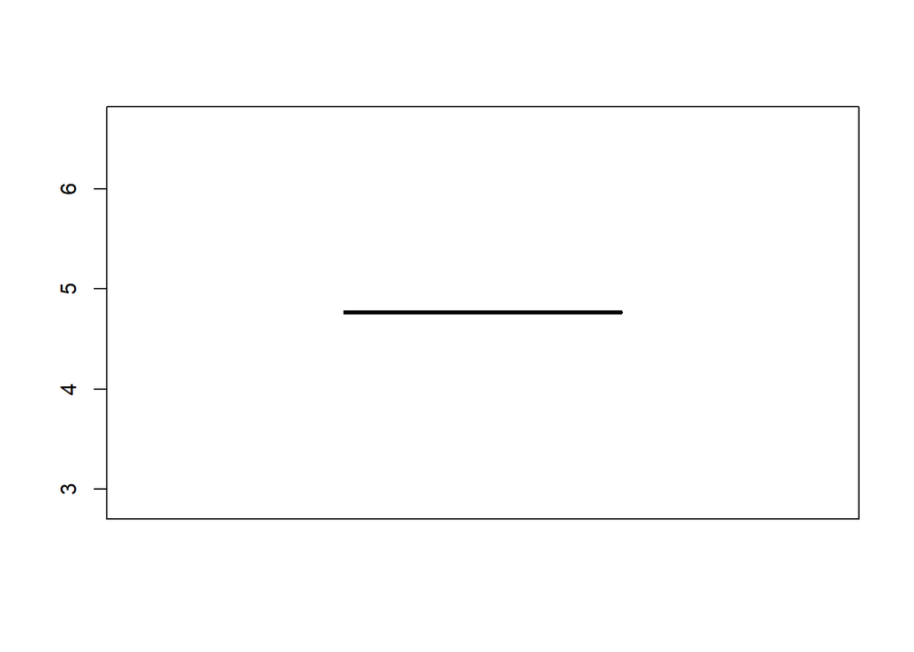

```r
boxplot(gmp)
```

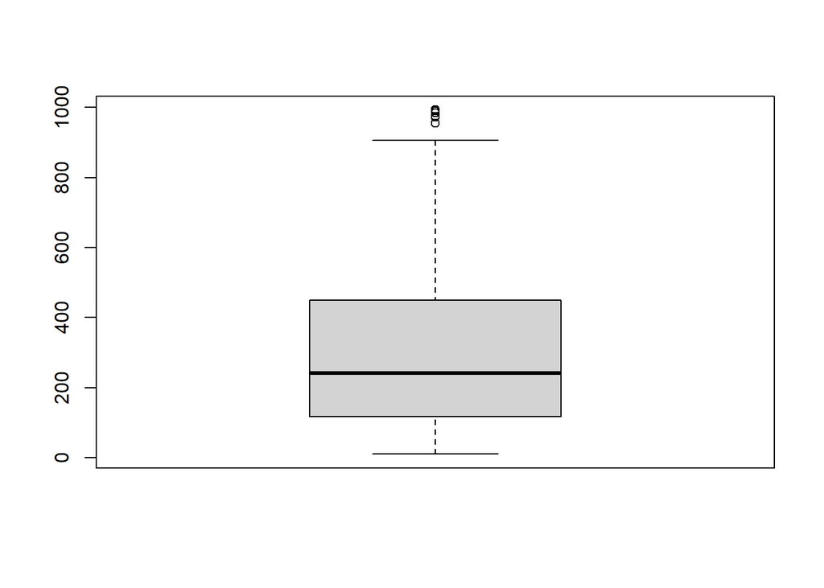

```r
boxplot(cogs)
```

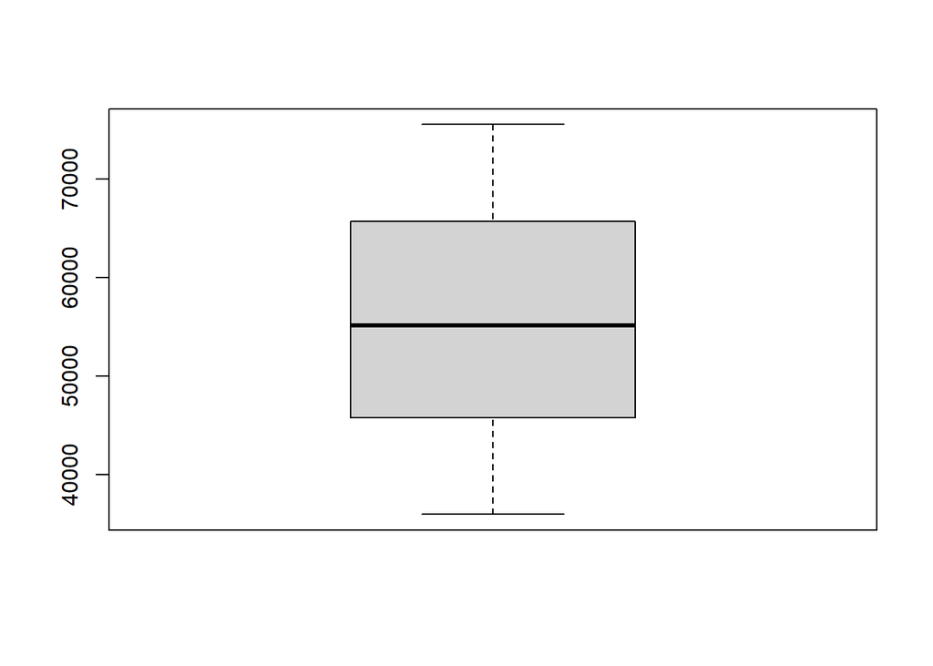

```r
boxplot(time)
```

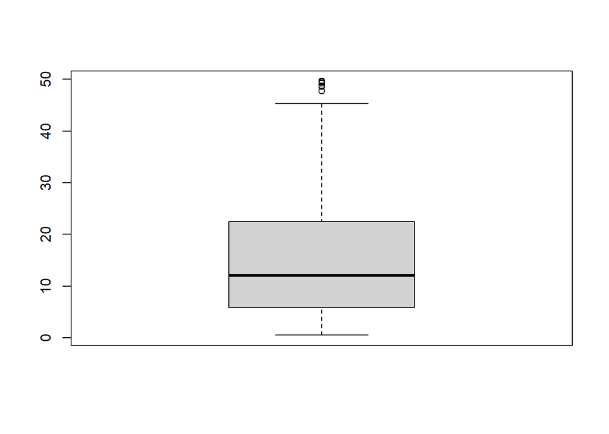

```r
boxplot(tax)
```

### 3. Dealing with Duplicates For data to qualify to be duplicated , there has to be identical row Items more than once.

```r
duplicated_all  = mall[duplicated(mall),]
duplicated_all
```

```
## # A tibble: 0 x 16
## # ... with 16 variables: `Invoice ID` <chr>, Branch <chr>, `Customer
## #   type` <chr>, Gender <chr>, `Product line` <chr>, `Unit price` <dbl>,
## #   Quantity <dbl>, Tax <dbl>, Date <chr>, Time <time>, Payment <chr>,
## #   cogs <dbl>, `gross margin percentage` <dbl>, `gross income` <dbl>,
## #   Rating <dbl>, Total <dbl>
```

```r
#From the data , none of the columns shows duplication
```

## 4. EXploratory Data Analysis

Exploratory data analysis is an approach to analyzing data sets to summarize their main characteristics, often with visual methods. A statistical model can be used or not, but primarily EDA is for seeing what the data can tell us beyond the formal modeling or hypothesis testing task

### 1.Measures of Central Tendency.

1. Mean #### We have extensively checked at Mean in the Summaries

b.median. #### We have extensively checked at Median values in the Summaries

c.Mode #### R - does not have an inbuilt R code for mode. Hence we will create our own function.

```r
getmode <- function(v){
  uniqv <- unique(v)
  uniqv[which.max(tabulate(match(v ,uniqv)))]
}
```

1. Mode of total

```r
getmode(total)
```

```
## [1] 829.08
```

2. Mode of Rate

```r
getmode(rate)
```

```
## [1] 6
```

3. Mode of Gross Income

```r
getmode(gross_income)
```

```
## [1] 39.48
```

Mode of GMP

```r
getmode(gmp)
```

```
## [1] 4.761905
```

Mode of Cogs

```r
getmode(cogs)
```

```
## [1] 789.6
```

Mode of pay

```r
getmode(pay)
```

```
## [1] "Ewallet"
```

Mode for time

```r
getmode(time)
```

```
## [1] 71280
```

Mode of tax

```r
getmode(tax)
```

```
## [1] 39.48
```

### .Dispresion of data

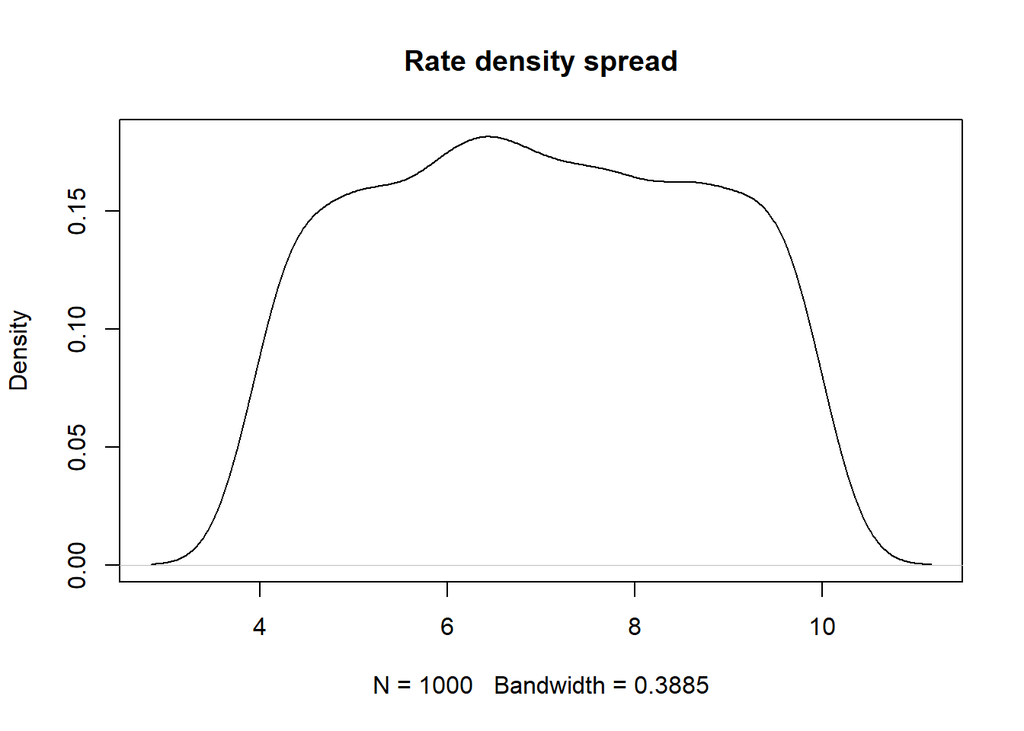

```r
#Spread of Rate
plot(density(rate), main = 'Rate density spread')
```

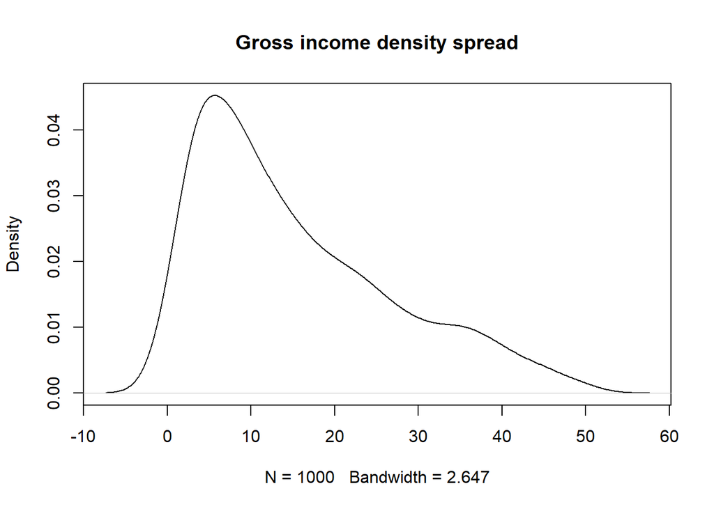

```r
#Spread of Gross income
plot(density(gross_income), main = 'Gross income density spread')
```

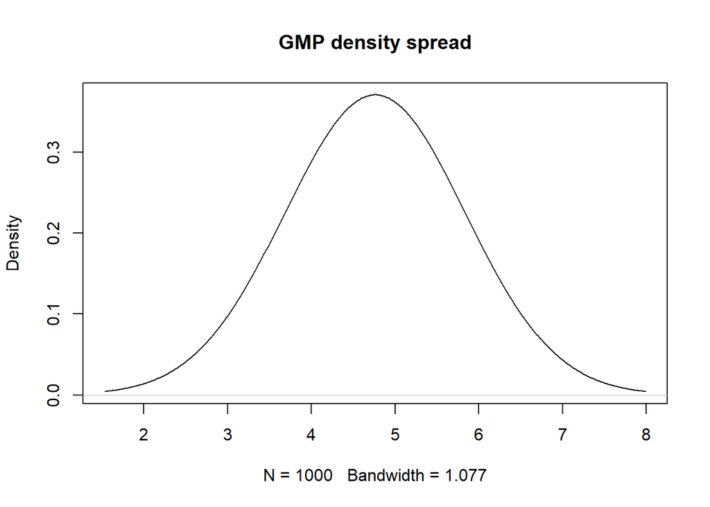

```r
#Spread of Gmp
plot(density(gmp), main = 'GMP density spread')
```

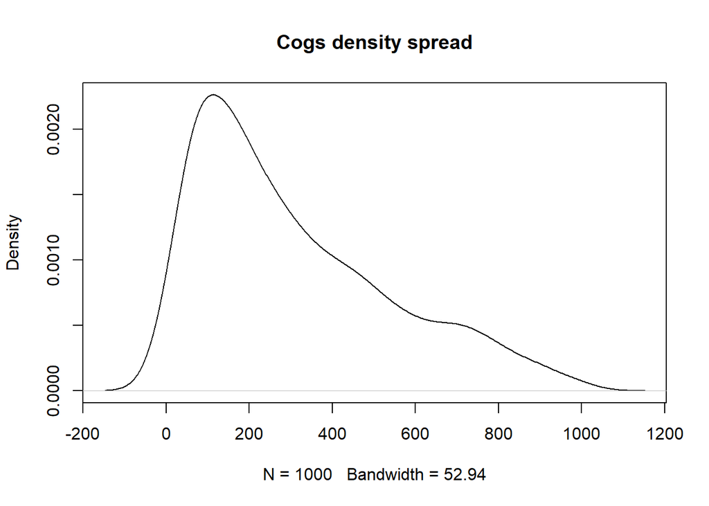

```r
#Spread of Gmp
plot(density(cogs), main = 'Cogs density spread')
```

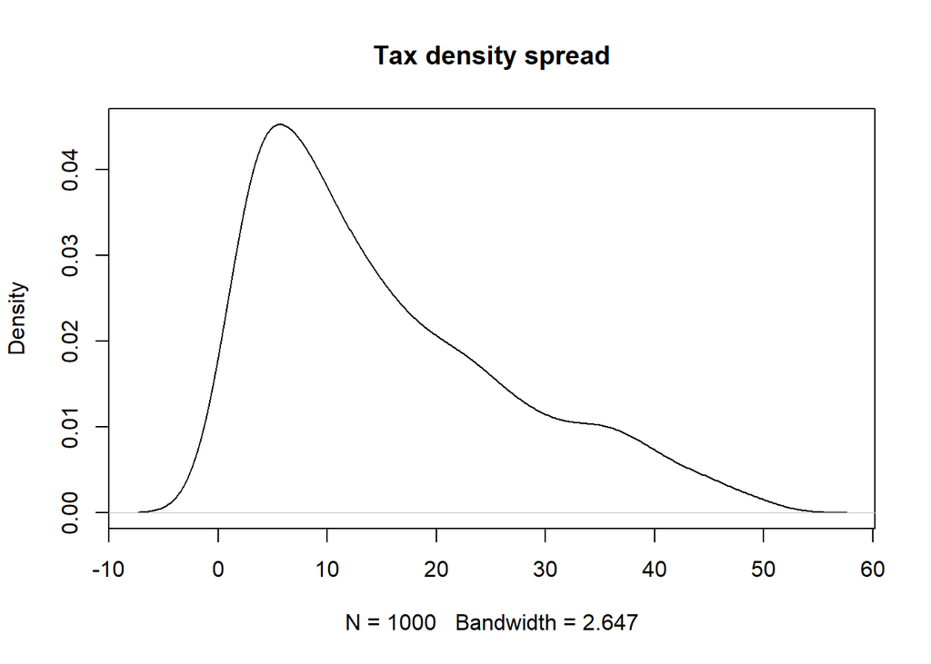

```r
#Spread of tax
plot(density(tax), main = 'Tax density spread')
```

```r
by(gross_income, rate, summary)
```

```
## rate: 4
##    Min. 1st Qu.  Median    Mean 3rd Qu.    Max.
##   2.321   6.004  11.011  17.258  29.315  32.796
## ------------------------------------------------------------
## rate: 4.1
##    Min. 1st Qu.  Median    Mean 3rd Qu.    Max.
##   1.531   3.735   4.768  10.054  10.647  35.516
## ------------------------------------------------------------
## rate: 4.2
##    Min. 1st Qu.  Median    Mean 3rd Qu.    Max.
##   2.661  12.619  15.962  20.078  28.690  44.982
## ------------------------------------------------------------
## rate: 4.3
##    Min. 1st Qu.  Median    Mean 3rd Qu.    Max.
##  0.9165  3.3904 13.1985 15.7622 25.9161 41.1700
## ------------------------------------------------------------
## rate: 4.4
##    Min. 1st Qu.  Median    Mean 3rd Qu.    Max.
##    2.43    4.03   14.31   18.81   28.02   48.69
## ------------------------------------------------------------
## rate: 4.5
##    Min. 1st Qu.  Median    Mean 3rd Qu.    Max.
##   2.896  12.002  21.028  22.466  32.791  49.260
## ------------------------------------------------------------
## rate: 4.6
##    Min. 1st Qu.  Median    Mean 3rd Qu.    Max.
##   1.649   8.121  14.668  15.679  24.485  29.028
## ------------------------------------------------------------
## rate: 4.7
##    Min. 1st Qu.  Median    Mean 3rd Qu.    Max.
##   1.950   3.245   7.196  15.089  29.402  38.184
## ------------------------------------------------------------
## rate: 4.8
##    Min. 1st Qu.  Median    Mean 3rd Qu.    Max.
##   3.449   8.400  12.210  16.300  21.510  47.790
## ------------------------------------------------------------
## rate: 4.9
##    Min. 1st Qu.  Median    Mean 3rd Qu.    Max.
##   2.772   6.143   9.181  14.506  17.676  48.685
## ------------------------------------------------------------
```

[output cut: 188 more lines]

```
## rate: 9.7
##    Min. 1st Qu.  Median    Mean 3rd Qu.    Max.
##   2.112   4.418   7.711  11.335  17.374  29.992
## ------------------------------------------------------------
## rate: 9.8
##    Min. 1st Qu.  Median    Mean 3rd Qu.    Max.
##   0.699   4.590  10.342  12.473  14.791  42.282
## ------------------------------------------------------------
## rate: 9.9
##    Min. 1st Qu.  Median    Mean 3rd Qu.    Max.
##   3.704   9.053  16.369  17.330  25.080  43.550
## ------------------------------------------------------------
## rate: 10
##    Min. 1st Qu.  Median    Mean 3rd Qu.    Max.
##   3.711  16.160  24.782  19.813  26.395  28.017
```

```r
by(gross_income, gmp, summary)
```

```
## gmp: 4.761904762
##    Min. 1st Qu.  Median    Mean 3rd Qu.    Max.
##  0.5085  5.9249 12.0880 15.3794 22.4453 49.6500
```

```r
#by(gross_income, total*,summary)
```

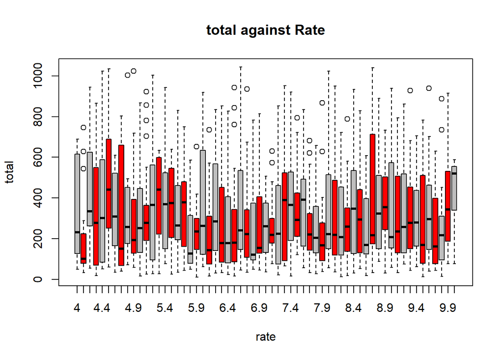

```r
boxplot(total~rate, col = c("grey", "red") , main ="total against Rate")
```

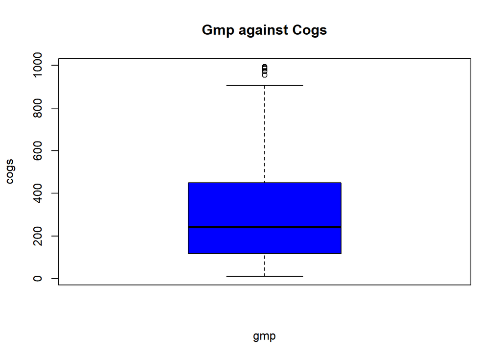

```r
boxplot(cogs~gmp, col = c("blue", "orange") , main ="Gmp against Cogs")
```

## PCA - Principal Component Analysis

lets check for Numerical variables.

```r
str(mall)
```

```
## tibble [1,000 x 16] (S3: spec_tbl_df/tbl_df/tbl/data.frame)
##  $ Invoice ID             : chr [1:1000] "750-67-8428" "226-31-3081" "631-41-3108" "123-19-1176" ...
##  $ Branch                 : chr [1:1000] "A" "C" "A" "A" ...
##  $ Customer type          : chr [1:1000] "Member" "Normal" "Normal" "Member" ...
##  $ Gender                 : chr [1:1000] "Female" "Female" "Male" "Male" ...
##  $ Product line           : chr [1:1000] "Health and beauty" "Electronic accessories" "Home and lifestyle" "Health and beauty" ...
##  $ Unit price             : num [1:1000] 74.7 15.3 46.3 58.2 86.3 ...
##  $ Quantity               : num [1:1000] 7 5 7 8 7 7 6 10 2 3 ...
##  $ Tax                    : num [1:1000] 26.14 3.82 16.22 23.29 30.21 ...
##  $ Date                   : chr [1:1000] "1/5/2019" "3/8/2019" "3/3/2019" "1/27/2019" ...
##  $ Time                   : 'hms' num [1:1000] 13:08:00 10:29:00 13:23:00 20:33:00 ...
##   ..- attr(*, "units")= chr "secs"
##  $ Payment                : chr [1:1000] "Ewallet" "Cash" "Credit card" "Ewallet" ...
##  $ cogs                   : num [1:1000] 522.8 76.4 324.3 465.8 604.2 ...
##  $ gross margin percentage: num [1:1000] 4.76 4.76 4.76 4.76 4.76 ...
##  $ gross income           : num [1:1000] 26.14 3.82 16.22 23.29 30.21 ...
##  $ Rating                 : num [1:1000] 9.1 9.6 7.4 8.4 5.3 4.1 5.8 8 7.2 5.9 ...
##  $ Total                  : num [1:1000] 549 80.2 340.5 489 634.4 ...
##  - attr(*, "spec")=
##   .. cols(
##   ..   `Invoice ID` = col_character(),
##   ..   Branch = col_character(),
##   ..   `Customer type` = col_character(),
##   ..   Gender = col_character(),
##   ..   `Product line` = col_character(),
##   ..   `Unit price` = col_double(),
##   ..   Quantity = col_double(),
##   ..   Tax = col_double(),
##   ..   Date = col_character(),
##   ..   Time = col_time(format = ""),
##   ..   Payment = col_character(),
##   ..   cogs = col_double(),
##   ..   `gross margin percentage` = col_double(),
##   ..   `gross income` = col_double(),
##   ..   Rating = col_double(),
##   ..   Total = col_double()
##   .. )
```

Now that we have the the numerical variables now one can define those variables. Avoid (categorical variables)

```r
#Check for SD, if any has Zero , remove it from the List of Numeric variables.
sd(unit)
```

```
## [1] 26.49463
```

```r
sd(quantity)
```

```
## [1] 2.923431
```

```r
sd(cogs)
```

```
## [1] 234.1765
```

```r
sd(gmp)
```

```
## [1] 0
```

```r
sd(gross_income)
```

```
## [1] 11.70883
```

```r
sd(rate)
```

```
## [1] 1.71858
```

```r
sd(total)
```

```
## [1] 245.8853
```

We then pass df to the prcomp(). We also set two arguments, center and scale, to be TRUE then preview our object with summary

```r
unit <- as.numeric(unit)
quantity <- as.numeric(quantity)
cogs <- as.numeric(cogs)
gmp <- as.numeric(gmp)
gross_income <- as.numeric(gross_income)
rate <- as.numeric(rate)
total <- as.numeric(total)
```

```r
df <- mall[,c(6,7,12,14,15)]
head(df)
```

```
## # A tibble: 6 x 5
##   `Unit price` Quantity  cogs `gross income` Rating
##          <dbl>    <dbl> <dbl>          <dbl>  <dbl>
## 1         74.7        7 523.           26.1     9.1
## 2         15.3        5  76.4           3.82    9.6
## 3         46.3        7 324.           16.2     7.4
## 4         58.2        8 466.           23.3     8.4
## 5         86.3        7 604.           30.2     5.3
## 6         85.4        7 598.           29.9     4.1
```

```r
mall.pca <- prcomp(df,
                   center = TRUE,
                   scale. = TRUE)
```

```r
print(mall.pca)
```

```
## Standard deviations (1, .., p=5):
## [1] 1.713608e+00 1.000165e+00 9.938726e-01 2.746573e-01 2.614503e-16
##
## Rotation (n x k) = (5 x 5):
##                      PC1          PC2          PC3         PC4           PC5
## Unit price   -0.38220491  0.275520080 -0.691623819  0.54741628 -4.804619e-16
## Quantity     -0.42491980 -0.210980897  0.634082085  0.61063093 -4.224901e-16
## cogs         -0.57992756  0.008357036  0.003668208 -0.40447586  7.071068e-01
## gross income -0.57992756  0.008357036  0.003668208 -0.40447586 -7.071068e-01
## Rating        0.02702985  0.937782526  0.345788216 -0.01624287  9.951763e-17
```

Have a look at the data types of Mall.pca

```r
summary(mall.pca)
```

```
## Importance of components:
##                           PC1    PC2    PC3     PC4       PC5
## Standard deviation     1.7136 1.0002 0.9939 0.27466 2.615e-16
## Proportion of Variance 0.5873 0.2001 0.1976 0.01509 0.000e+00
## Cumulative Proportion  0.5873 0.7874 0.9849 1.00000 1.000e+00
```

# Installing our ggbiplot visualisation package

```r
library(devtools)
library(usethis)
```

```r
install_github("vqv/ggbiplot")
```

```
## Skipping install of 'ggbiplot' from a github remote, the SHA1 (7325e880) has not changed since last install.
##   Use `force = TRUE` to force installation
```

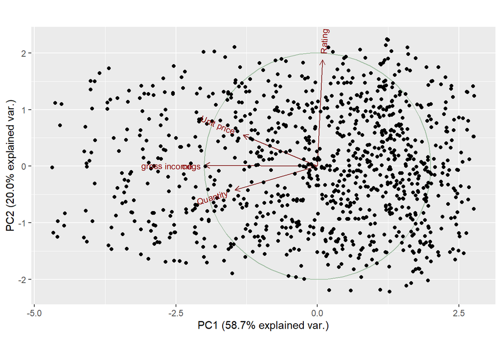

```r
library(ggbiplot)
plot = ggbiplot(mall.pca , obs.scale = 1 , var.scale = 1 ,ellipse = TRUE, circle = TRUE)
plot1 = plot + scale_color_discrete(name = '') + theme(legend.direction = 'horizontal')
plot1
```